# 18/19 DPH101 final C.Compare More Than Two Means

dizhen

2019.12.27

## C.Compare More Than Two Means

### Step1. Data

```r
LEVELS <- c(0.637,0.354,0.287,0.533,0.228,0.632,0.303,0.194,0.293,0.276,0.226,0.395,0.994,0.89,0.809,0.321,0.712,0.949,0.933,0.28,0.336,0.678,0.714,0.757)
TEMPERATURE <- factor(c(rep(0, times = 6), rep(1, times=6),
                  rep(0, times = 6), rep(1, times = 6)),
                labels = c("Unheated", "Heated"))
SOURCES <- factor(c(rep(0, times = 12), rep(1, times=12)),
                labels = c("Juice", "Chromoplast"))
mydata <- data.frame(LEVELS,TEMPERATURE,SOURCES)
str(mydata)
```

```
## 'data.frame':    24 obs. of  3 variables:
##  $ LEVELS     : num  0.637 0.354 0.287 0.533 0.228 0.632 0.303 0.194 0.293 0.276 ...
##  $ TEMPERATURE: Factor w/ 2 levels "Unheated","Heated": 1 1 1 1 1 1 2 2 2 2 ...
##  $ SOURCES    : Factor w/ 2 levels "Juice","Chromoplast": 1 1 1 1 1 1 1 1 1 1 ...
```

```r
head(mydata)
```

```
##   LEVELS TEMPERATURE SOURCES
## 1  0.637    Unheated   Juice
## 2  0.354    Unheated   Juice
## 3  0.287    Unheated   Juice
## 4  0.533    Unheated   Juice
## 5  0.228    Unheated   Juice
## 6  0.632    Unheated   Juice
```

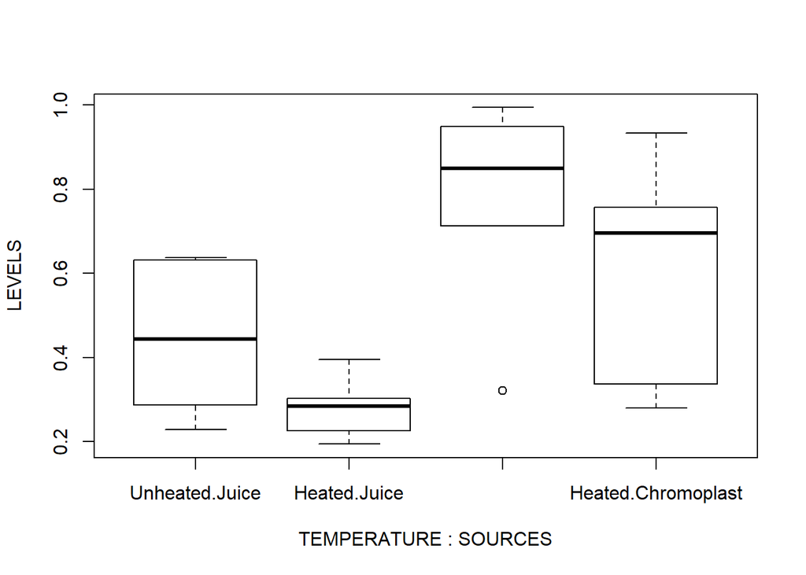

```r
boxplot(LEVELS ~ TEMPERATURE * SOURCES,
        data = mydata)
```

### Step4. Test Statistic

F = MS(source)/MS(error) F = MS(temperature)/MS(error) F = MS(interaction)/MS(error)

### Step5. Distribution of the Test Statistic

We use F distribution

### Step7. Calculation of test statistic

### Step8. Statistical decision

As the significance level is 0.05, only p-value of effect of sources is less than 0.05, so only the null hypothesis of no effect of sources can be rejected. We fail to reject other nul hypothesis of no effect of temperature or no effect of interaction.

```r
LEVELS.AOV <- aov(LEVELS ~ TEMPERATURE * SOURCES,
                    data = mydata)
summary(LEVELS.AOV)
```

```
##                     Df Sum Sq Mean Sq F value Pr(>F)
## TEMPERATURE          1 0.1602  0.1602   3.947 0.0608 .
## SOURCES              1 0.6717  0.6717  16.546 0.0006 ***
## TEMPERATURE:SOURCES  1 0.0000  0.0000   0.000 0.9944
## Residuals           20 0.8119  0.0406
## ---
## Signif. codes:  0 '***' 0.001 '**' 0.01 '*' 0.05 '.' 0.1 ' ' 1
```

### Step9. Conclusion

We conclude that there is an effect of sources while no effect of temperature or interaction on the serum concentration of beta-carotene in ferrets.

### A single model

Write down a single model to assess the effect of temperature and source on serum concentration of beta-carotene, allowing for the posibility that differences between mean concentrations of different sources vary by temperature.

$$x_{ijk} = \mu + \alpha_i + \beta_j + (\alpha \beta)_{ij} + \varepsilon_{ijk}$$

where i = 1,2, j = 1,2, k = 1,2,3,4,5,6

$x_{ijk}$ is a typical observation

$\mu$ is an unknown constant

$\alpha_i$ is the effect due to sources

$\beta_i$ is the effect due to temperatures

$(\alpha \beta)_{ij}$ is the effect due to interaction of temperatures and sources

$\varepsilon_{ijk}$ is the error term representing all other sources of variation